# Лабораторная работа № 14

Настройка файловых служб Samba

Баранов Никита Дмитриевич

1132242977@rudn.ru

Российский университет дружбы народов им. Патриса Лумумбы

2026-09-14

# Информация

## Докладчик

- Баранов Никита Дмитриевич
- Студент РУДН
- 1132242977@rudn.ru

# Цель и задачи

## Цель работы

- Получить навыки настройки группового доступа к общим ресурсам по SMB.

## Основные этапы

- Установлены samba, samba-client и cifs-utils; созданы sambagroup и пароль SMB.
- В smb.conf добавлен sambashare с записью для sambagroup.
- Служба smb запущена; testparm и smbclient -L подтвердили конфигурацию и видимость ресурса.
- Для firewalld открыты samba и samba-client, каталог получил группу и SELinux-контекст samba_share_t.
- Клиент смонтировал //server.ndbaranov.net/sambashare в /mnt/samba и создал тестовый файл.
- Учётные данны вынесены в файл credentials, а монтирование закреплено в /etc/fstab.
- Сценарии Samba для server и client успешно выполнены.

# Ход работы

## Установка Samba

- На server установлены samba, samba-client и cifs-utils, создана группа sambagroup.

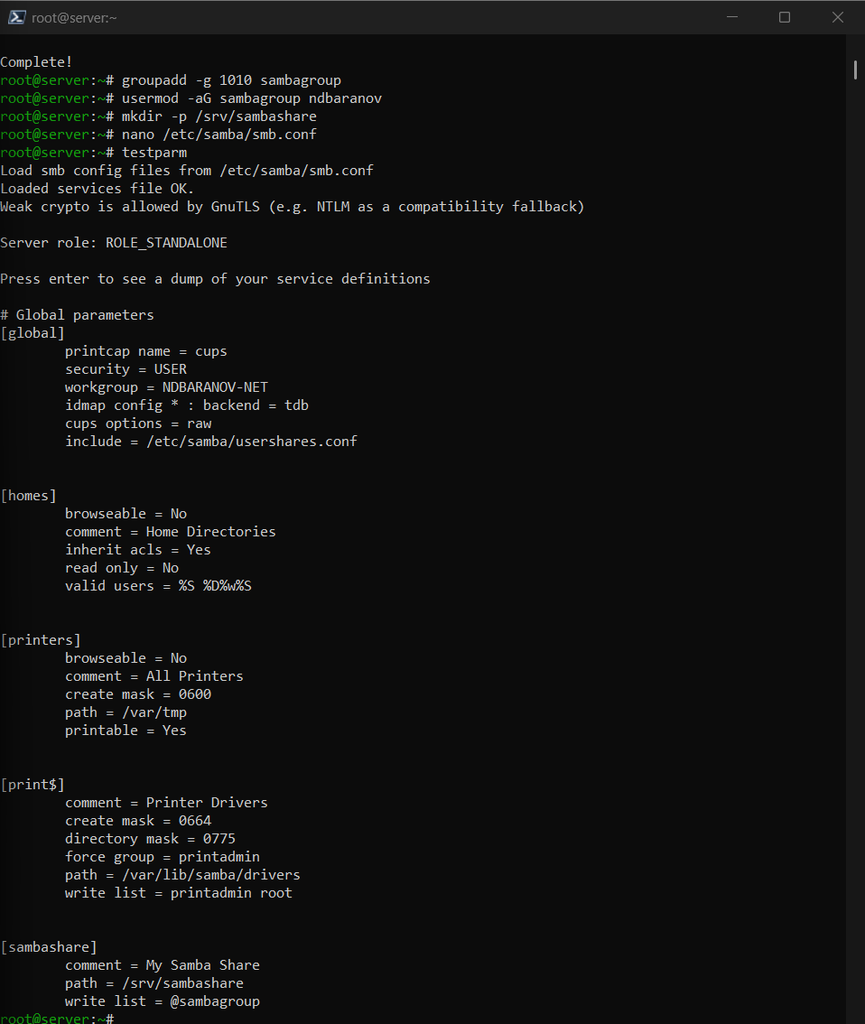

## Учётная запись Samba

- Пользователь добавлен в базу smbpasswd и включён для сетевой аутентификации.

[figure not shown]

## Ресурс sambashare

- В smb.conf описан общий каталог sambashare с разрешением записи для нужной группы.

[figure not shown]

## Запуск службы SMB

- Служба smb включена и запущена.

[figure not shown]

## Обнаружение общих ресурсов

- smbclient -L выводит sambashare в списке доступных ресурсов.

[figure not shown]

## SELinux и firewalld

- Каталог получил контекст samba_share_t, а в firewalld разрешён сервис samba.

[figure not shown]

## Подключение CIFS

- Клиент смонтировал //server.ndbaranov.net/sambashare в /mnt/samba.

[figure not shown]

## Проверка записи

- Через подключённый ресурс создан тестовый файл; он отображается и на сервере.

[figure not shown]

## Credentials, fstab и provision

- Учётные данные вынесены в защищённый файл, монтирование добавлено в fstab, затем выполнены provision-сценарии Samba.

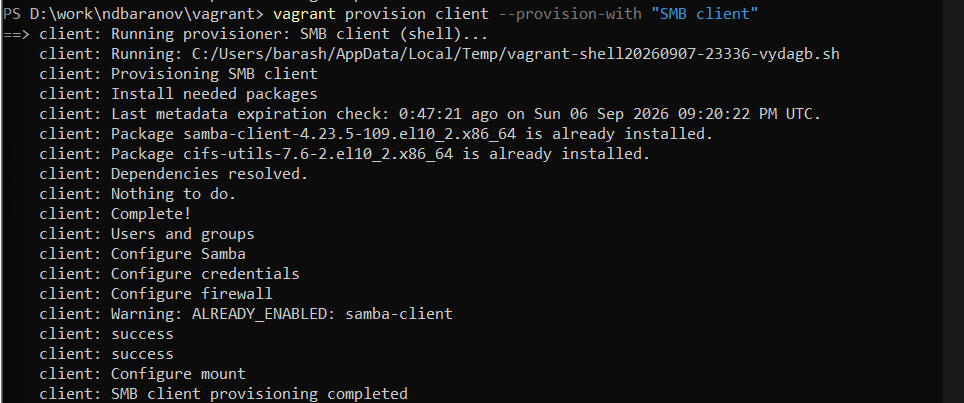

# Результаты

## Итоги работы

- Samba предоставляет общий ресурс по SMB с групповой аутентификацией. CIFS-монтирование и создание файла подтверждают сетевую доступность и права на запись.

## Спасибо за внимание